# Car Speed by observing Road Type and Time

## Road Type Records

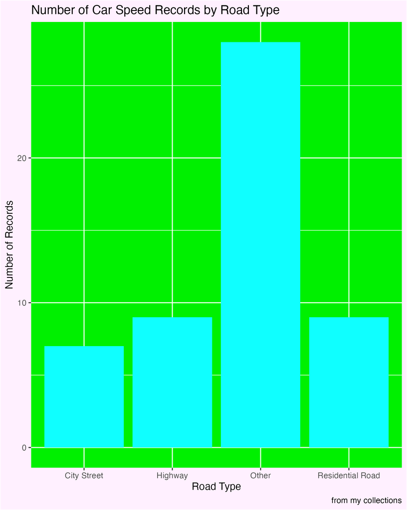

A bar chart shows the number of car speed for Highway, Residential road, City street and other road type.

This first visualization shows that how many car speed records were collected for each road type, and it would help to compare the amount of data observing collections across different road types and help to show whether the data is balanced across the three road categories. In this plot, “Other” represents records where the road type did not match the keywords used for Highway, City Street or Residential Road when I used `str_detect()` to classify the `road_type` variable. For example, some responses may come from people who did not own a driving licence, so their observations would not be clearly matched with the three main Road Types.

## Average Speed by Road Type

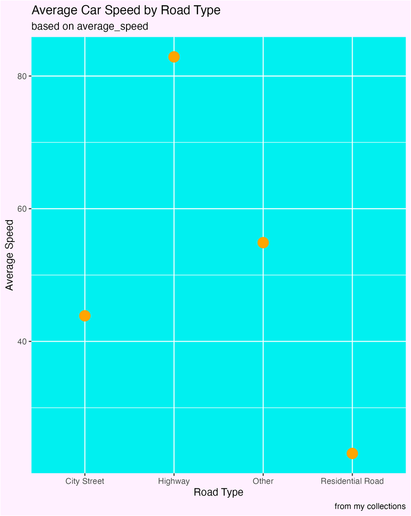

A point plot shows the average car speed for each road type.

This second visualization shows that the comparison of average observed speed across different types of road, and it contains whether road types tend to have higher or lower observing speed.For example, highways may be expected to have higher average speeds than residential roads because of different driving environment. I kept the “Other” group in this plot to keep the classification consistent with the first visualization. However, it does not mean that “Other” is a road type, so its average speed may be interpreted carefully.

## Speed by Time and Road Type

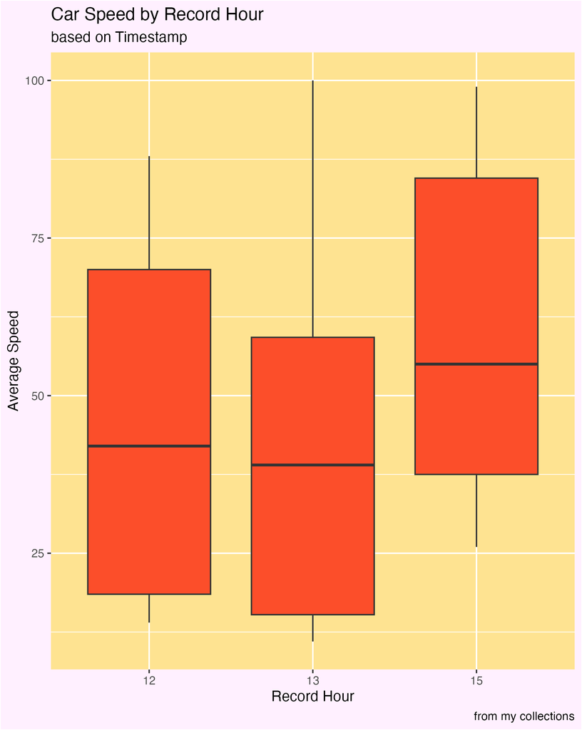

A box plot shows the distribution of car speed by record hour using timestamp data.

This third visualization shows that the `Timestamp` was converted into a date-time value using the `lubridate` package, and the record hour was used to compare speed pattern in different hours. This would help connect the speed observations with the time when data was recorded. It makes the visual data story more complete, because it not only compare road types, but also considers when the observations were made.